# DA3_1_paziczki_peter_161117

Peter Paziczki

2017 november 12

# DA3 assignment #1

Individual assignment

## Problem 1.1

Download hotels_all_nov21.csv. Pick a city. Consider hotels and hostels. Consider all with at least 2 stars. You have 7 tasks (1p each):

### 1. Filter the data to the city of your choice and other characteristcs (stars, accomodaton type) . Describe the distributon of the price and distance variables. Comment on graphs. (1-2 sentences)

I chose Rome to investigate. There are 785 different accommodations in town, of which 773 are hotels and 12 are hostels. I dropped the hotels and hostels that have less than 2 stars, meaning that 42 hotels and 12 hostels have been dropped. Basically we dropped all the hostels from the data, so we have 731 hotels to investigate.

I created a histogram of price variable not grouping it by the nuber of stars:

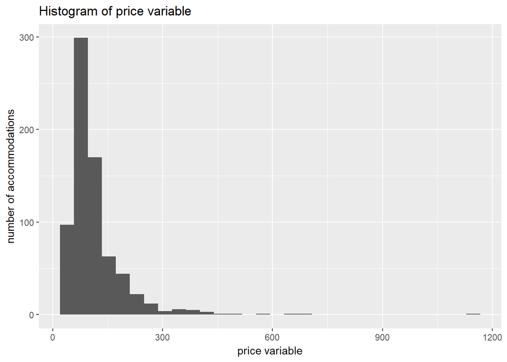

We can see that the histogram shows us a log normal like distribution that is skewed to the right with a long tail. The range of price variable is quite big, there are a few obvservations in the 1050-1200EUR price range. The most observation can be found in the 0-150EUR range.

Let’s see the distribution of accommodations by the number of stars:

| stars | N |
| --- | --- |
| 2 | 96 |
| 3 | 312 |
| 4 | 284 |
| 5 | 37 |
| 3.5 | 2 |

We can see that the most of the variables have 3 or 4 stars, and only a smaller fraction of accommodations have other star ratings.

Let’s have a look at the histograms of price variable by the number of stars.

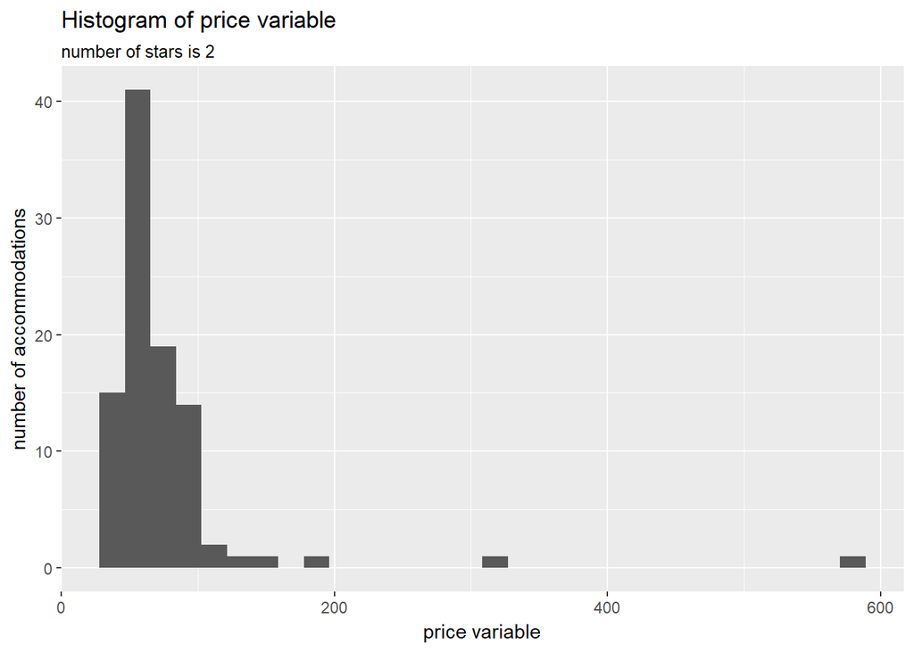

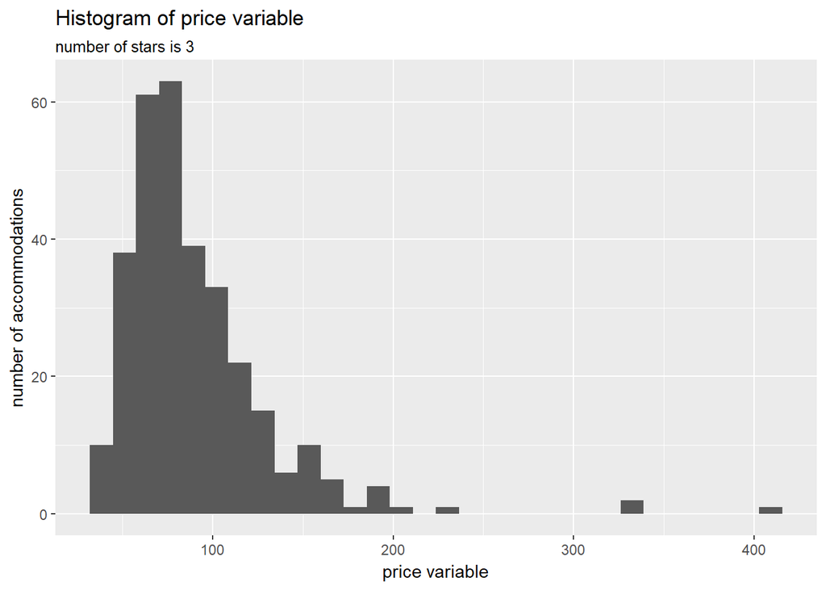

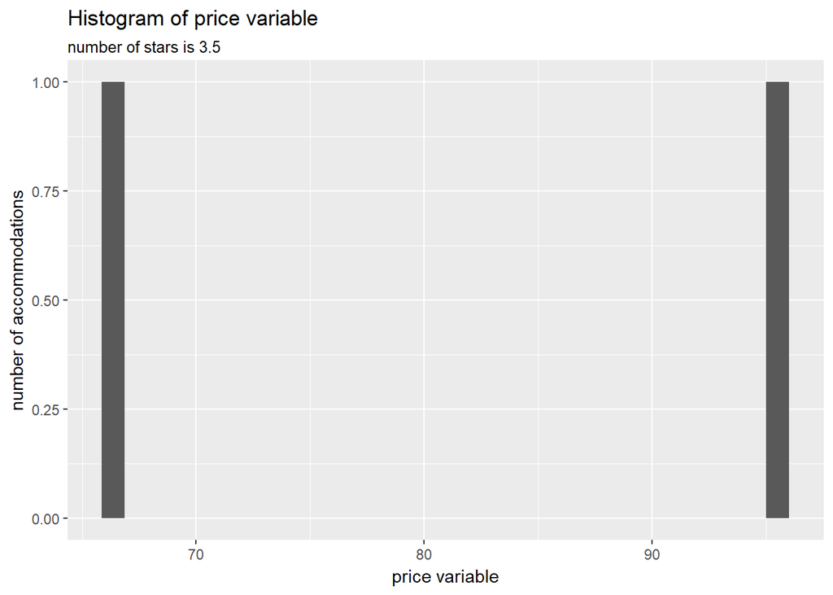

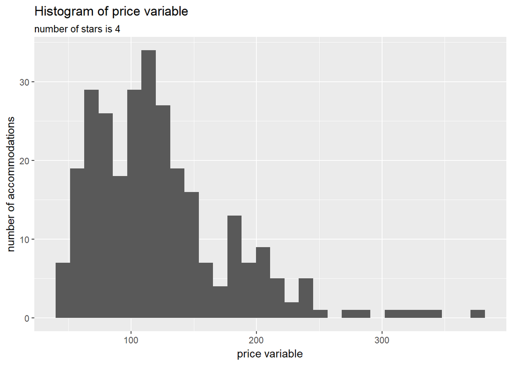

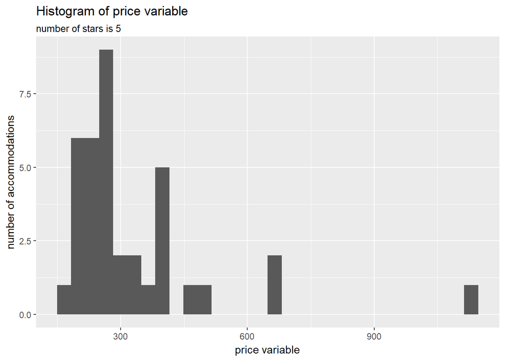

There are only 2 observations with star 3.5, it has a Bernoulli like distribution. But in all the other four cases the histograms show us log normal like distributions that are skewed to the right. In all cases we can observe more extreme values.

We need to assess the distribution by distance instead of price.

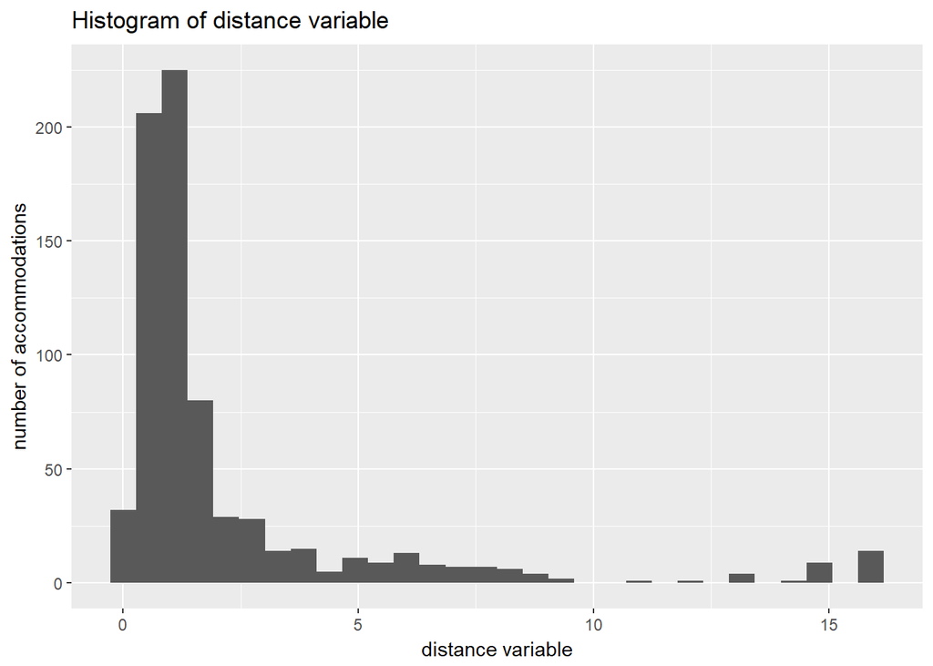

We can see that the distribution has a log normal like distribution with quite a long right tail. The range is more than 15km. There are only a few observation in the far range 10-12.5km. Most of the observations are in the first bin in the 0-2.5km range.

Now let’s have a look at the distribution of distance variable grouped by the number of stars.

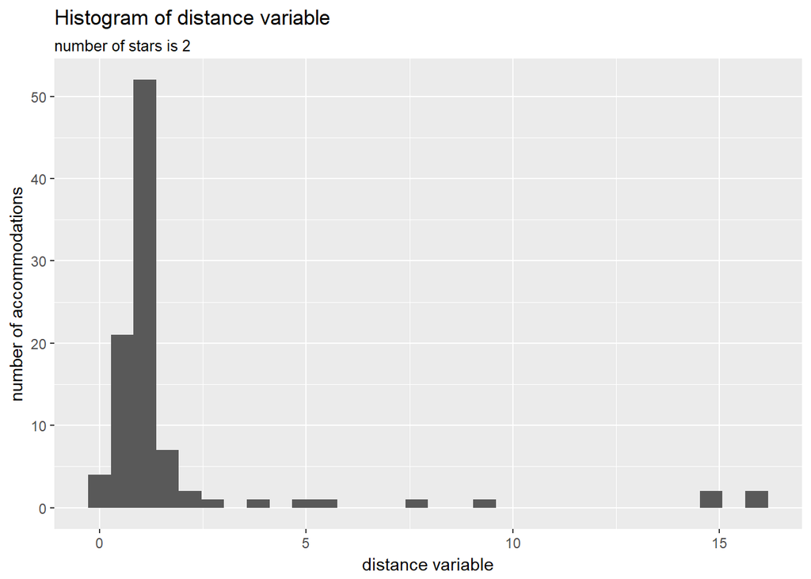

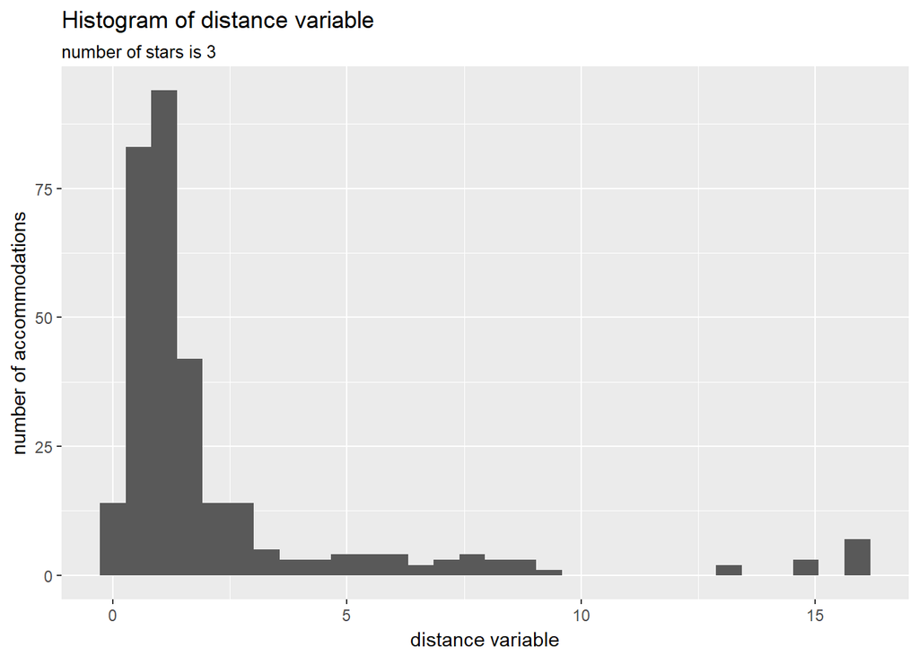

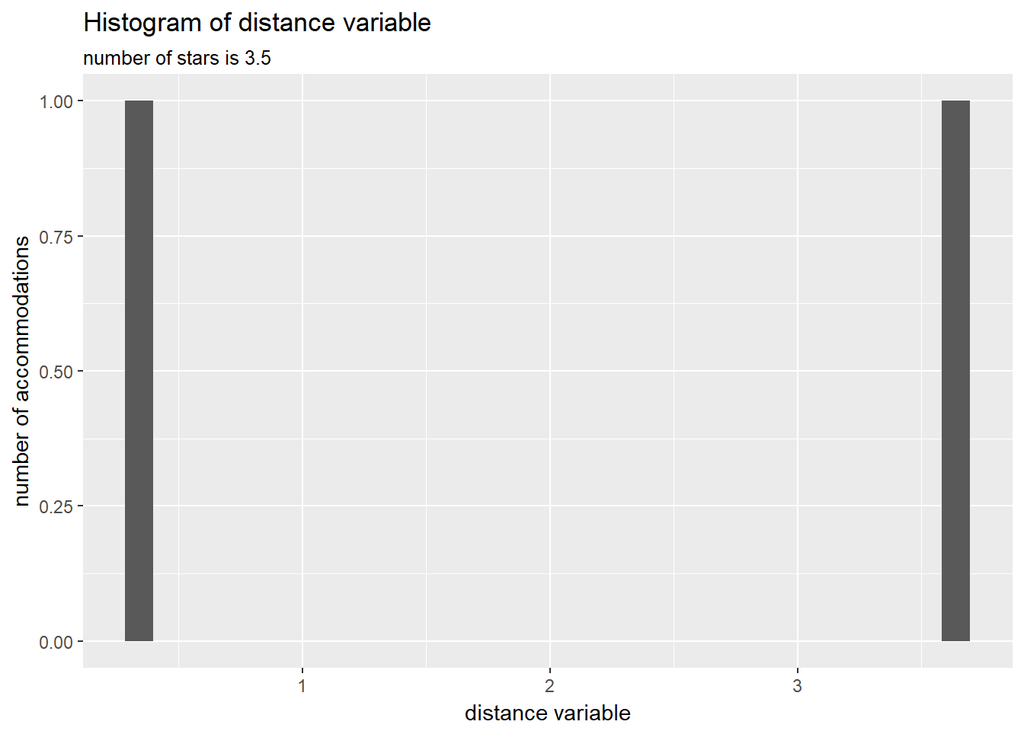

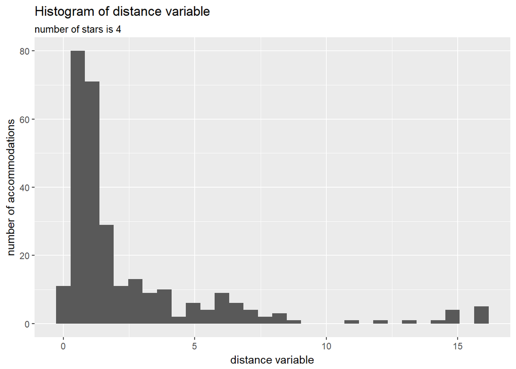

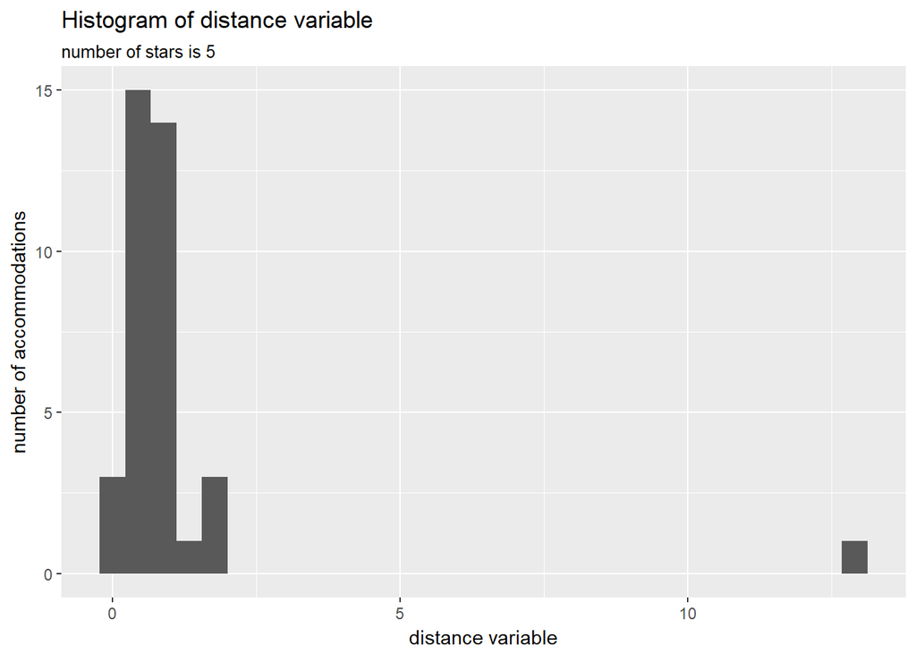

In case of 5 star hotels there are no observation in the 2.5-12.5km range at all. The hotels with 3.5 stars have the same Bernoulli like distribution as they had when assessing the price variable. In the other cases the distributions seem to be log normal like and are skewed to the right.

### 2. Sample defniton: You may or may not want to drop some observatons; make a choice and argue for it (1-2 sentences).

Let’s have a look at the scatterplot:

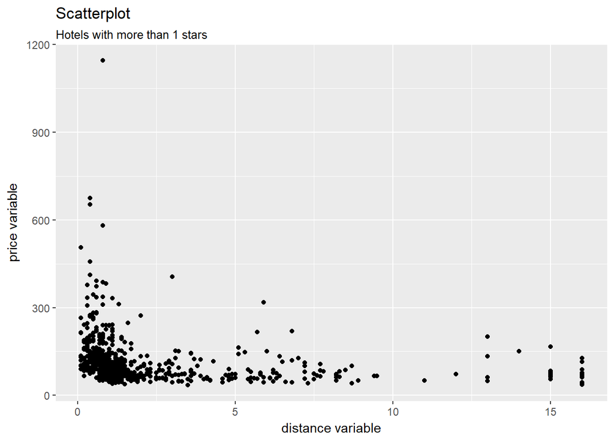

There are hotels that are far from the city center, they can be in the suburbs or in the agglomeration, I will exclude them. Furthermore there are only a few observations far from the city center, I will focus on the denser areas. The more observation we have, the better statistics we can create. I will narrow the investigation down to hotels with 3, 3.5 and 4 stars.

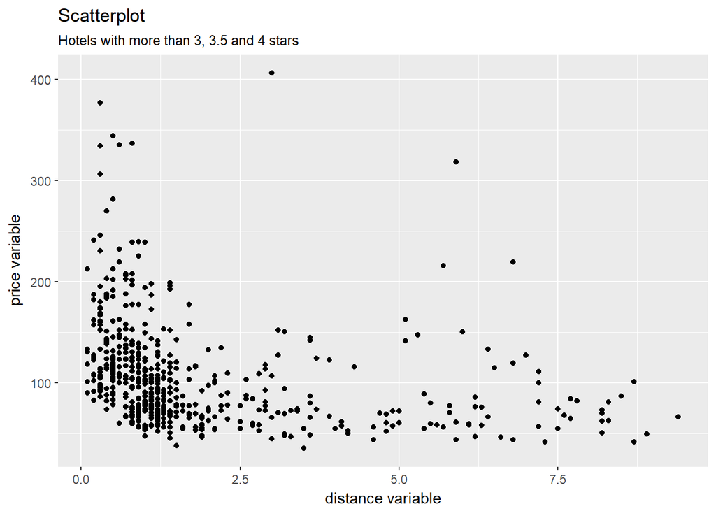

### 3. Create a binary variable of distance (below/above cutoﬀ of your choice) and regress price on this binary variable. Report, interpret and visualize the results. (1-2 sentences)

I chose the cutoff to be at 2km. All the hotels that are closer to city center thank 2km will be marked as *Close*, and *far* otherwise.

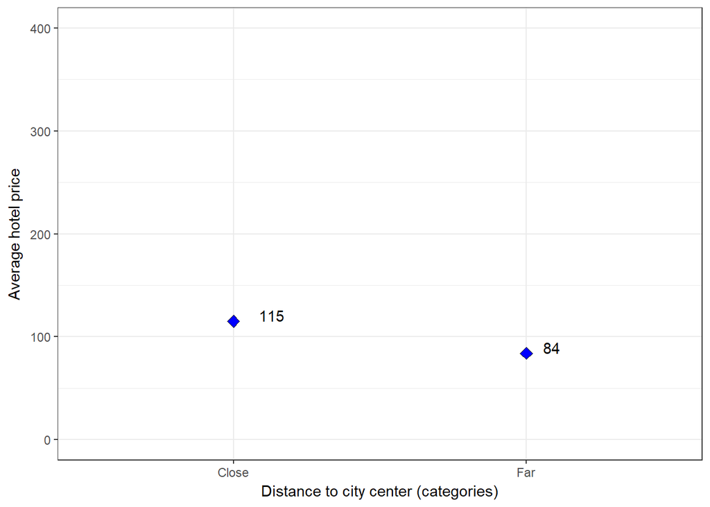

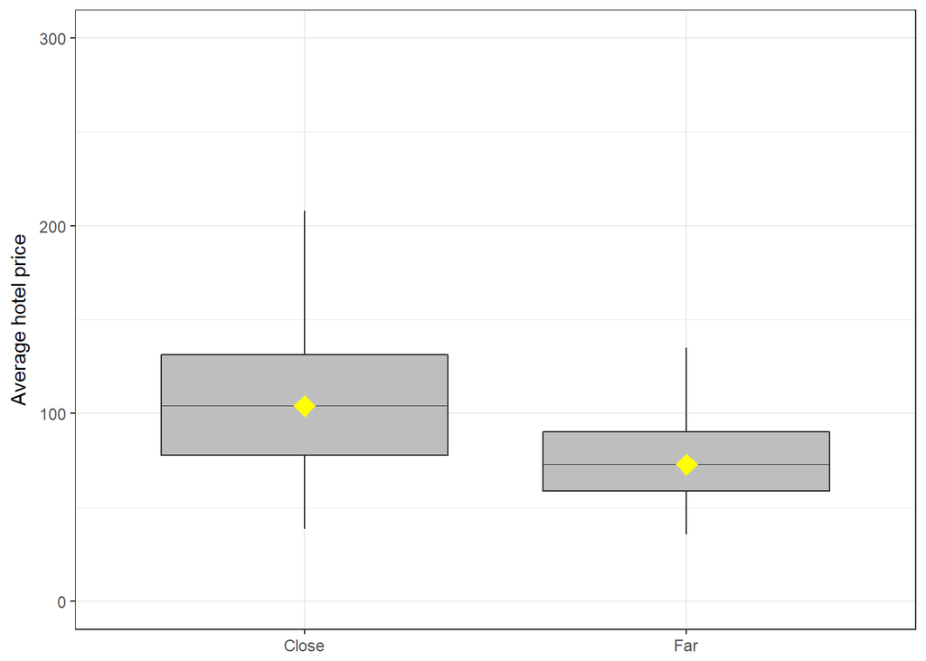

### 4. Estmate a lowess nonparametric regression of price on distance. Report, interpret and visualize the results. (1-2 sentences)

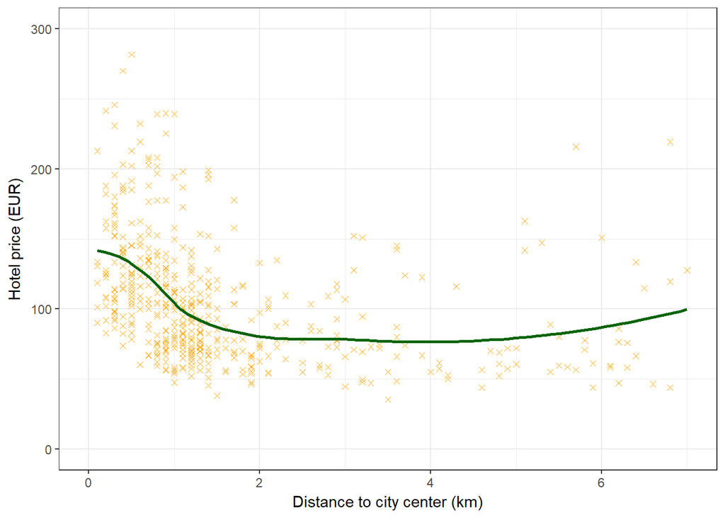

### 5. Estimate a simple linear regression of price on distance. Report, interpret and visualize the results. (1-2 sentences)

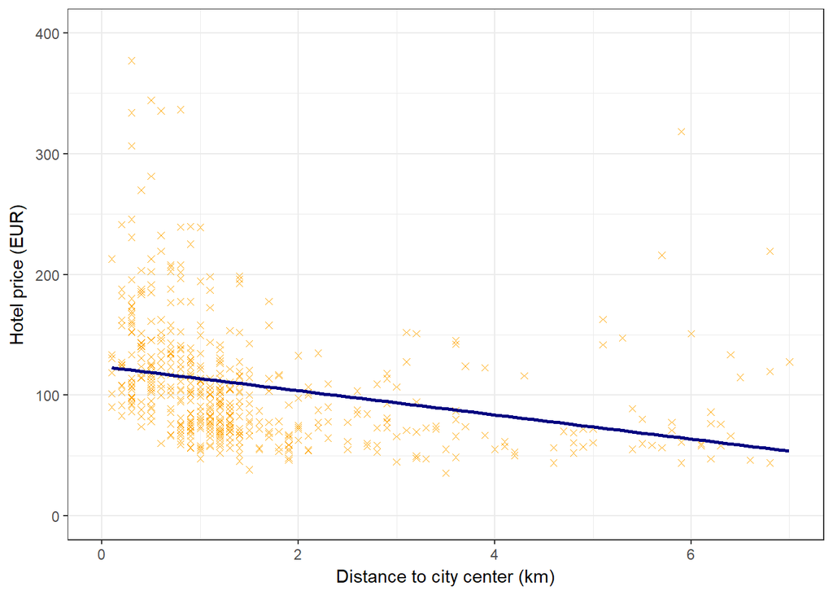

### 6. Estmate a linear regression of price on distance that captures potental nonlinearites (polynomials, splies). Report, interpret and visualize the results. (1-2 sentences)

```
##
## Call:
## lm(formula = price ~ lspline(distance, 2), data = Rome_3)
##
## Residuals:
##    Min     1Q Median     3Q    Max
## -69.03 -28.74 -10.62  15.82 330.33
##
## Coefficients:
##                       Estimate Std. Error t value Pr(>|t|)
## (Intercept)            152.996      4.636   33.00   <2e-16 ***
## lspline(distance, 2)1  -39.512      3.917  -10.09   <2e-16 ***
## lspline(distance, 2)2    2.020      1.590    1.27    0.204
## ---
## Signif. codes:  0 '***' 0.001 '**' 0.01 '*' 0.05 '.' 0.1 ' ' 1
##
## Residual standard error: 47.23 on 570 degrees of freedom
## Multiple R-squared:  0.186,  Adjusted R-squared:  0.1831
## F-statistic: 65.12 on 2 and 570 DF,  p-value: < 2.2e-16
```

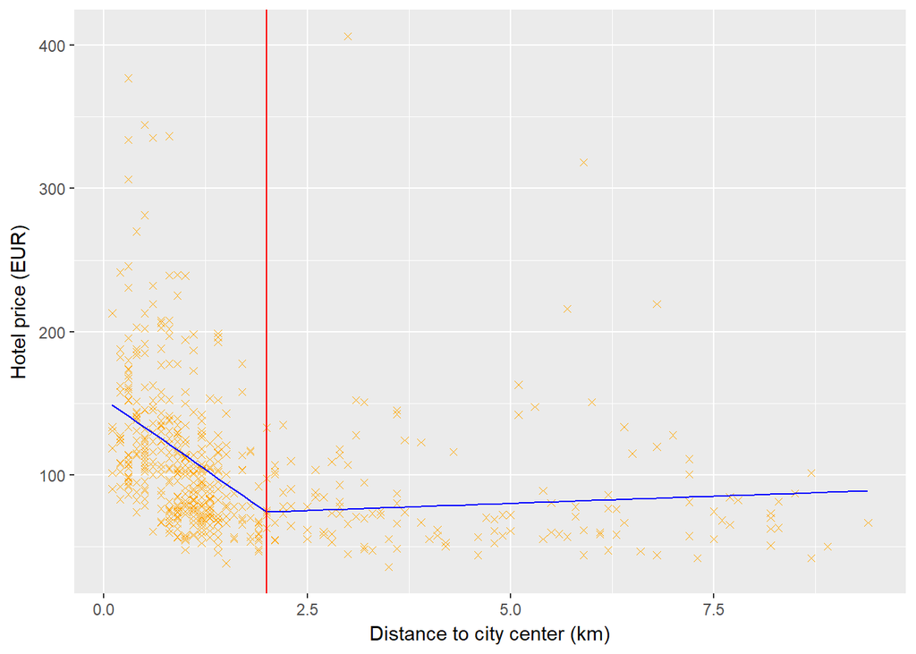

```
##
## Call:
## lm(formula = price ~ lspline(distance, c(1, 4)), data = Rome_3)
##
## Residuals:
##    Min     1Q Median     3Q    Max
## -74.89 -29.10 -10.89  15.09 320.46
##
## Coefficients:
##                             Estimate Std. Error t value Pr(>|t|)
## (Intercept)                 172.2912     6.7766  25.424   <2e-16 ***
## lspline(distance, c(1, 4))1 -72.8112     8.4803  -8.586   <2e-16 ***
## lspline(distance, c(1, 4))2  -6.8094     2.7945  -2.437   0.0151 *
## lspline(distance, c(1, 4))3   0.5462     3.0219   0.181   0.8566
## ---
## Signif. codes:  0 '***' 0.001 '**' 0.01 '*' 0.05 '.' 0.1 ' ' 1
##
## Residual standard error: 47.09 on 569 degrees of freedom
## Multiple R-squared:  0.1925, Adjusted R-squared:  0.1882
## F-statistic: 45.21 on 3 and 569 DF,  p-value: < 2.2e-16
```

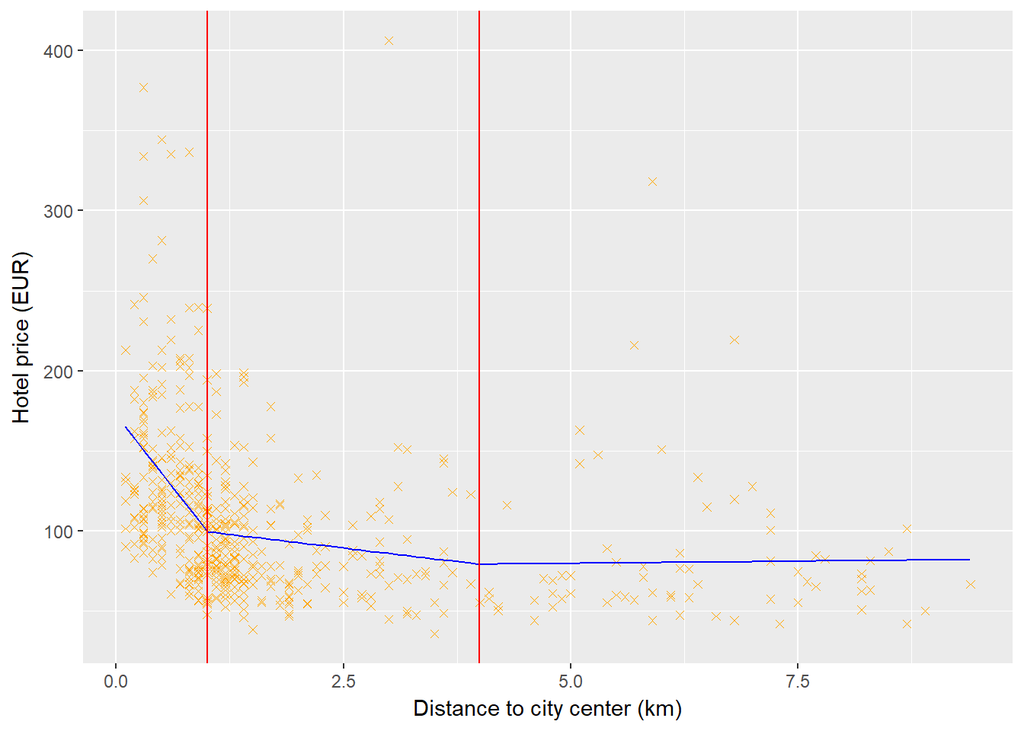

### 7. Discuss your overall fndings. (2-3 sentences)